# Final Project Report

HeeJun Son, Khamidov Sarvar, and Isha Thukral

12/15/21

```r
# clean up the RStudio environment
rm(list = ls())

# load all packages here: `mosaic`, `tidyverse`, `lubridate`, and all others used
library(tidyverse)
library(mosaicData)
library(esquisse)
library(dcData)
library(lubridate)
library(ggplot2)
library(readr)
```

### Data Access

```r
 # Tip: Scroll right if browser settings cut off the URL
cities_internet_prices_historical_24_10_2021 <- read_csv("cities_internet_prices_historical.24-10-2021.csv")
 # Tip: Scroll right if browser settings cut off the URL
GDP <- read_csv("GDP.csv")
```

```r
head(cities_internet_prices_historical_24_10_2021)
```

| City | Region | Country | Internet Price, 2010 | Internet Price, 2011 | Internet Price, 2012 | Internet Price, 2013 | Internet Price, 2014 | Internet Price, 2015 | Internet Price, 2016 | Internet Price, 2017 | Internet Price, 2018 | Internet Price, 2019 | Internet Price, 2020 |
| --- | --- | --- | --- | --- | --- | --- | --- | --- | --- | --- | --- | --- | --- |
| New York City | New York | United States of America | 42.99000 | 49.99833 | 42.25000 | 55.93200 | 50.28500 | 53.45840 | 54.59267 | 59.23640 | 61.45813 | 61.73458 | 66.44140 |
| Washington, D.C. | District of Columbia | United States of America | 35.00000 | 48.00000 | 49.28571 | 45.83333 | 47.00000 | 56.33259 | 59.16967 | 64.20708 | 64.92308 | 69.14975 | 60.59045 |
| San Francisco | California | United States of America | 41.66667 | 42.50000 | 36.50000 | 48.50000 | 47.00000 | 55.26143 | 53.05138 | 58.77778 | 63.24603 | 67.36667 | 68.98882 |
| Berlin | NA | Germany | 30.86420 | 38.61836 | 20.50926 | 30.05102 | 32.56588 | 27.12971 | 26.47066 | 32.46713 | 36.43968 | 33.92292 | 35.82708 |
| Los Angeles | California | United States of America | 35.75000 | 43.62500 | 41.50000 | 37.50000 | 40.32100 | 47.60647 | 50.84164 | 56.28288 | 57.48411 | 63.01485 | 66.69022 |
| Bern | Canton of Bern | Switzerland | 0.00000 | 0.00000 | 51.54639 | 55.55556 | 0.00000 | 46.18368 | 40.16687 | 54.15721 | 0.00000 | 52.48137 | 0.00000 |

```r
head(GDP)
```

| Country | Country Code | 1990 | 1991 | 1992 | 1993 | 1994 | 1995 | 1996 | 1997 | 1998 | 1999 | 2000 | 2001 | 2002 | 2003 | 2004 | 2005 | 2006 | 2007 | 2008 | 2009 | 2010 | 2011 | 2012 | 2013 | 2014 | 2015 | 2016 | 2017 | … |
| --- | --- | --- | --- | --- | --- | --- | --- | --- | --- | --- | --- | --- | --- | --- | --- | --- | --- | --- | --- | --- | --- | --- | --- | --- | --- | --- | --- | --- | --- | --- |
| Aruba | ABW | 24101.109 | 25870.756 | 26533.344 | 27430.752 | 28656.520 | 28648.990 | 28499.089 | 30215.949 | 30512.684 | 30728.054 | 33120.054 | 32117.912 | 30862.2227 | 31387.2830 | 34176.4646 | 35207.577 | 36362.219 | 37865.493 | 38515.264 | 34693.087 | 33732.847 | 35492.618 | 35498.982 | 37419.893 | 38223.372 | 38249.055 | 38390.272 | 39454.630 | … |
| Afghanistan | AFG | NA | NA | NA | NA | NA | NA | NA | NA | NA | NA | NA | NA | 839.4859 | 888.1534 | 885.8408 | 979.274 | 1031.643 | 1176.126 | 1218.118 | 1454.663 | 1637.378 | 1626.765 | 1806.764 | 1874.766 | 1897.526 | 1886.693 | 1896.993 | 1934.637 | … |
| Angola | AGO | 3089.683 | 3120.356 | 2908.161 | 2190.768 | 2195.532 | 2496.199 | 2794.897 | 2953.343 | 3027.342 | 3037.721 | 3097.307 | 3191.266 | 3564.0960 | 3614.6073 | 3978.6972 | 4555.186 | 5048.876 | 5697.251 | 6221.423 | 6092.783 | 6230.297 | 6346.395 | 6772.528 | 6980.423 | 7199.245 | 7096.601 | 6756.935 | 6650.585 | … |
| Albania | ALB | 2549.473 | 1909.114 | 1823.308 | 2057.450 | 2289.873 | 2665.765 | 2980.066 | 2717.362 | 3021.015 | 3471.653 | 3861.334 | 4301.353 | 4661.3716 | 4994.5188 | 5422.7785 | 5865.306 | 6559.783 | 7276.303 | 8228.374 | 8814.811 | 9628.026 | 10207.752 | 10526.235 | 10571.011 | 11259.226 | 11662.030 | 11868.179 | 12930.140 | … |
| Arab World | ARB | 6808.207 | 6872.273 | 7255.328 | 7458.647 | 7645.683 | 7774.207 | 8094.150 | 8397.516 | 8797.663 | 8938.452 | 9415.633 | 9584.108 | 9581.7971 | 9974.6419 | 10937.3161 | 11646.486 | 12442.188 | 13041.926 | 13739.728 | 13640.847 | 14127.778 | 14518.827 | 15423.465 | 15824.780 | 16153.245 | 16501.793 | 16935.383 | 17099.889 | … |
| United Arab Emirates | ARE | 72906.520 | 71753.730 | 71567.828 | 70082.389 | 72471.687 | 74994.381 | 76848.792 | 80390.064 | 77421.109 | 76654.256 | 82215.314 | 80843.605 | 79863.4897 | 82946.3352 | 85147.2191 | 81635.468 | 79970.736 | 72802.162 | 66641.484 | 56975.529 | 54230.174 | 56574.288 | 58961.202 | 62641.837 | 66443.998 | 70212.093 | 72386.090 | 73137.870 | … |

```r
summary(cities_internet_prices_historical_24_10_2021)
```

```
     City              Region            Country          Internet Price, 2010 Internet Price, 2011
 Length:695         Length:695         Length:695         Min.   : 0.000       Min.   : 0.000
 Class :character   Class :character   Class :character   1st Qu.: 0.000       1st Qu.: 0.000
 Mode  :character   Mode  :character   Mode  :character   Median : 0.000       Median : 0.000
                                                          Mean   : 5.047       Mean   : 9.863
                                                          3rd Qu.: 0.000       3rd Qu.: 0.000
                                                          Max.   :95.351       Max.   :94.937
 Internet Price, 2012 Internet Price, 2013 Internet Price, 2014 Internet Price, 2015
 Min.   :  0.00       Min.   :  0.00       Min.   :  0.00       Min.   :  0.00
 1st Qu.:  0.00       1st Qu.:  0.00       1st Qu.:  0.00       1st Qu.:  0.00
 Median :  0.00       Median :  0.00       Median :  0.00       Median : 16.17
 Mean   : 13.45       Mean   : 15.06       Mean   : 15.79       Mean   : 21.14
 3rd Qu.: 24.61       3rd Qu.: 29.22       3rd Qu.: 30.04       3rd Qu.: 40.45
 Max.   :305.00       Max.   :130.92       Max.   :321.01       Max.   :377.91
 Internet Price, 2016 Internet Price, 2017 Internet Price, 2018 Internet Price, 2019
 Min.   :  0.00       Min.   :  0.00       Min.   :  0.00       Min.   :  0.000
 1st Qu.:  0.00       1st Qu.:  0.00       1st Qu.: 11.60       1st Qu.:  8.993
 Median : 24.37       Median : 18.17       Median : 34.52       Median : 31.747
 Mean   : 25.99       Mean   : 24.37       Mean   : 35.48       Mean   : 32.967
 3rd Qu.: 45.81       3rd Qu.: 48.63       3rd Qu.: 57.75       3rd Qu.: 55.535
 Max.   :259.64       Max.   :111.60       Max.   :225.84       Max.   :134.364
 Internet Price, 2020
 Min.   :  0.00
 1st Qu.:  0.00
 Median : 20.78
 Mean   : 26.86
 3rd Qu.: 49.44
 Max.   :109.55
```

```r
summary(GDP)
```

```
   Country          Country Code            1990              1991              1992
 Length:260         Length:260         Min.   :  424.8   Min.   :  324.6   Min.   :  301
 Class :character   Class :character   1st Qu.: 1718.3   1st Qu.: 1674.0   1st Qu.: 1725
 Mode  :character   Mode  :character   Median : 3823.3   Median : 3911.3   Median : 4125
                                       Mean   : 7319.1   Mean   : 7515.8   Mean   : 7689
                                       3rd Qu.: 9225.5   3rd Qu.: 9424.9   3rd Qu.: 9133
                                       Max.   :72906.5   Max.   :71753.7   Max.   :71568
                                       NA's   :51        NA's   :49        NA's   :47
      1993              1994              1995              1996              1997
 Min.   :  327.3   Min.   :  342.4   Min.   :  345.1   Min.   :  379.1   Min.   :  417.8
 1st Qu.: 1707.2   1st Qu.: 1691.0   1st Qu.: 1775.6   1st Qu.: 1972.8   1st Qu.: 2108.3
 Median : 4371.5   Median : 4362.7   Median : 4556.5   Median : 4824.2   Median : 5098.4
 Mean   : 7874.1   Mean   : 8094.0   Mean   : 8593.1   Mean   : 8933.7   Mean   : 9518.4
 3rd Qu.: 9582.8   3rd Qu.: 9774.7   3rd Qu.:10137.4   3rd Qu.:10708.4   3rd Qu.:11802.8
 Max.   :70082.4   Max.   :72471.7   Max.   :74994.4   Max.   :76848.8   Max.   :80390.1
 NA's   :45        NA's   :42        NA's   :36        NA's   :36        NA's   :35
      1998              1999              2000              2001              2002
 Min.   :  452.7   Min.   :  469.1   Min.   :  455.8   Min.   :  443.6   Min.   :  450.4
 1st Qu.: 2193.3   1st Qu.: 2294.6   1st Qu.: 2370.0   1st Qu.: 2429.7   1st Qu.: 2353.3
 Median : 5324.6   Median : 5555.4   Median : 5987.1   Median : 6199.4   Median : 6425.6
 Mean   :10022.0   Mean   :10369.1   Mean   :11229.9   Mean   :11572.7   Mean   :11895.3
 3rd Qu.:12158.4   3rd Qu.:12678.4   3rd Qu.:13276.0   3rd Qu.:13945.6   3rd Qu.:14470.1
 Max.   :77421.1   Max.   :76654.3   Max.   :86169.4   Max.   :88138.4   Max.   :92091.3
 NA's   :34        NA's   :33        NA's   :24        NA's   :23        NA's   :22
      2003              2004             2005            2006               2007
 Min.   :  469.8   Min.   :   499   Min.   :  529   Min.   :   555.8   Min.   :   587
 1st Qu.: 2539.7   1st Qu.:  2715   1st Qu.: 2918   1st Qu.:  3153.0   1st Qu.:  3342
 Median : 6645.0   Median :  7279   Median : 7795   Median :  8514.3   Median :  9243
 Mean   :12347.7   Mean   : 13222   Mean   :13956   Mean   : 15085.3   Mean   : 15997
 3rd Qu.:14512.4   3rd Qu.: 15445   3rd Qu.:16636   3rd Qu.: 18756.5   3rd Qu.: 20483
 Max.   :91451.6   Max.   :101329   Max.   :97769   Max.   :107541.5   Max.   :109363
 NA's   :22        NA's   :22       NA's   :22      NA's   :22         NA's   :21
      2008               2009               2010               2011             2012
 Min.   :   615.1   Min.   :   616.7   Min.   :   646.3   Min.   :   682   Min.   :   719.9
 1st Qu.:  3484.1   1st Qu.:  3695.0   1st Qu.:  3832.6   1st Qu.:  3871   1st Qu.:  4193.1
 Median : 10045.0   Median : 10028.3   Median : 10227.3   Median : 11040   Median : 11839.6
 Mean   : 16571.6   Mean   : 16185.0   Mean   : 16760.3   Mean   : 17478   Mean   : 18149.1
 3rd Qu.: 21289.9   3rd Qu.: 20678.1   3rd Qu.: 21569.9   3rd Qu.: 22959   3rd Qu.: 24645.6
 Max.   :111256.0   Max.   :108953.7   Max.   :117518.7   Max.   :124025   Max.   :126618.4
 NA's   :20         NA's   :19         NA's   :19         NA's   :17       NA's   :19
      2013               2014               2015               2016               2017
 Min.   :   699.6   Min.   :   710.8   Min.   :   744.7   Min.   :   743.9   Min.   :   738
 1st Qu.:  4398.4   1st Qu.:  4545.0   1st Qu.:  4771.5   1st Qu.:  4969.3   1st Qu.:  5149
 Median : 12169.1   Median : 12540.8   Median : 13039.1   Median : 13643.2   Median : 14184
 Mean   : 18760.5   Mean   : 19119.1   Mean   : 19513.4   Mean   : 19998.6   Mean   : 20836
 3rd Qu.: 25999.0   3rd Qu.: 25782.5   3rd Qu.: 26890.9   3rd Qu.: 27594.4   3rd Qu.: 29014
 Max.   :139962.2   Max.   :137833.0   Max.   :123822.1   Max.   :123573.6   Max.   :124609
 NA's   :19         NA's   :20         NA's   :22         NA's   :22         NA's   :22
      2018            2019
 Min.   :   744.2   Mode:logical
 1st Qu.:  4953.2   NA's:260
 Median : 14623.7
 Mean   : 21134.6
 3rd Qu.: 29900.0
 Max.   :126898.4
 NA's   :29
```

```r
tail(cities_internet_prices_historical_24_10_2021)
```

| City | Region | Country | Internet Price, 2010 | Internet Price, 2011 | Internet Price, 2012 | Internet Price, 2013 | Internet Price, 2014 | Internet Price, 2015 | Internet Price, 2016 | Internet Price, 2017 | Internet Price, 2018 | Internet Price, 2019 | Internet Price, 2020 |
| --- | --- | --- | --- | --- | --- | --- | --- | --- | --- | --- | --- | --- | --- |
| Santa Cruz de Tenerife | Canary Islands | Spain | 0 | 0.00000 | 0.00000 | 0.00000 | 0.00000 | 0.00000 | 0.00000 | 41.42409 | 47.10187 | 0.00000 | 0.00000 |
| Stavanger | Rogaland | Norway | 0 | 54.58256 | 73.56792 | 0.00000 | 54.69117 | 46.51002 | 43.17220 | 53.66032 | 63.47938 | 53.50738 | 0.00000 |
| Antwerp | Flemish Region | Belgium | 0 | 62.80193 | 61.72840 | 32.20779 | 46.26208 | 49.83607 | 47.45147 | 44.22302 | 55.93834 | 53.23105 | 54.13623 |
| Zaragoza | Aragon | Spain | 0 | 0.00000 | 0.00000 | 0.00000 | 0.00000 | 0.00000 | 42.57010 | 0.00000 | 0.00000 | 45.52001 | 31.84238 |
| Arlington | Virginia | United States of America | 0 | 0.00000 | 0.00000 | 0.00000 | 0.00000 | 0.00000 | 57.50000 | 61.00000 | 68.00000 | 60.84500 | 58.87500 |
| Jubail | Eastern Province | Saudi Arabia | 0 | 0.00000 | 0.00000 | 0.00000 | 0.00000 | 0.00000 | 46.66293 | 0.00000 | 65.76901 | 52.15832 | 0.00000 |

```r
tail(GDP)
```

| Country | Country Code | 1990 | 1991 | 1992 | 1993 | 1994 | 1995 | 1996 | 1997 | 1998 | 1999 | 2000 | 2001 | 2002 | 2003 | 2004 | 2005 | 2006 | 2007 | 2008 | 2009 | 2010 | 2011 | 2012 | 2013 | 2014 | 2015 | 2016 | 2017 | … |
| --- | --- | --- | --- | --- | --- | --- | --- | --- | --- | --- | --- | --- | --- | --- | --- | --- | --- | --- | --- | --- | --- | --- | --- | --- | --- | --- | --- | --- | --- | --- |
| Samoa | WSM | 2397.691 | 2404.131 | 2431.862 | 2566.287 | 2530.607 | 2734.052 | 2964.616 | 3019.213 | 3106.291 | 3205.724 | 3487.170 | 3790.587 | 3994.695 | 4226.804 | 4513.227 | 4816.582 | 5027.897 | 5454.116 | 5579.016 | 5313.758 | 5360.970 | 5655.137 | 5480.606 | 5505.993 | 5570.621 | 5831.526 | 6336.646 | 6495.388 | … |
| Kosovo | XKX | NA | NA | NA | NA | NA | NA | NA | NA | NA | NA | 3688.088 | 4782.380 | 4820.697 | 5200.329 | 5476.113 | 5983.304 | 6390.420 | 6983.879 | 7249.409 | 7506.899 | 7782.875 | 8222.286 | 8547.652 | 8903.763 | 9194.742 | 9781.020 | 10208.858 | 10756.663 | … |
| Yemen, Rep. | YEM | 2223.029 | 2325.264 | 2443.920 | 2472.189 | 2569.649 | 2657.813 | 2730.145 | 2829.866 | 2946.082 | 3015.155 | 3181.384 | 3278.904 | 3363.240 | 3452.738 | 3581.825 | 3789.889 | 3915.385 | 4038.656 | 4148.557 | 4221.414 | 4472.726 | 3876.303 | 3935.167 | 4084.883 | 4045.500 | 3320.110 | 2827.691 | 2645.308 | … |
| South Africa | ZAF | 6424.502 | 6414.058 | 6261.716 | 6331.778 | 6520.867 | 6719.583 | 7000.802 | 7179.807 | 7180.857 | 7348.952 | 7719.256 | 7994.262 | 8315.443 | 8613.587 | 9136.414 | 9796.155 | 10524.346 | 11240.260 | 11667.850 | 11416.002 | 11728.160 | 12179.174 | 12488.216 | 12815.727 | 13090.477 | 13185.253 | 13188.030 | 13438.283 | … |
| Zambia | ZMB | 1517.926 | 1528.781 | 1499.340 | 1600.348 | 1457.628 | 1493.124 | 1572.973 | 1616.493 | 1584.007 | 1636.148 | 1691.967 | 1773.964 | 1835.248 | 1948.532 | 2087.213 | 2248.466 | 2434.454 | 2637.278 | 2819.651 | 3017.025 | 3269.794 | 3419.010 | 3634.780 | 3765.584 | 3893.549 | 3927.762 | 3998.004 | 4090.120 | … |
| Zimbabwe | ZWE | 1829.678 | 1949.733 | 1777.843 | 1807.226 | 1986.028 | 2004.362 | 2227.061 | 2303.830 | 2377.832 | 2377.128 | 2344.271 | 2421.531 | 2235.361 | 1885.511 | 1818.105 | 1759.358 | 1738.514 | 1705.901 | 1417.507 | 1581.162 | 1888.567 | 2168.110 | 2534.542 | 2583.986 | 2648.569 | 2679.580 | 2687.385 | 2825.725 | … |

# Reasearch Guided Question

Does the GDP of a country affect internet prices by either increasing or decreasing it?

## Origin

We have found this data on Kaggle initially, and it represents internet prices across the world ranging from 2010-2020. The data seems to originate from the City API project site, but unfortunately, we could not retrieve information regarding the data/ data collector’s origins after further research. But from exploring the website https://city-api.io/en/ they seem to provide data about the worldwide related activity. They merge data sources to fit the client’s pressing questions. Some of the features are paid, but our data related to worldwide internet prices is free. This data was collected to show a trend in internet prices over the years spanning the entire world to notice trends in fees and other related factors. Finally, the last time the data was updated was a month ago, making the tables relatively up to date and accurate.

## Importance/ Interesting to Investing

This issue, also known as the “digital divide,” prevents pupils from developing countries from gaining access to the Internet and from connecting in this ever-globalizing market. Many people believe that Internet access should be a fundamental human right. Everyone needs equal access to the information and opportunities available from computers connected to the Internet. Unfortunately, access to computing devices and the Internet is unevenly distributed. Some people don’t have any computing devices, some have high-speed Internet on their home computers, and some are in the middle. This difference in access is the digital divide and is often due to socio-economic, geographical, or demographic factors. For example, a country like Norway has 96% citizens with internet access, while Somalia has merely 2% of the population. Hence it is essential to witness a thorough correlation analysis to see how internet prices and GDP plays a role. We chose GDP as our second data set as we see a general trend with countries with higher GDP having accessibility to the Internet while developing countries experience the opposite.

```r
# Rename variable name according to R programming Style Guide
internet <-
  cities_internet_prices_historical_24_10_2021 %>%
  rename("i2010" = "Internet Price, 2010",
         "i2011" = "Internet Price, 2011",
         "i2012" = "Internet Price, 2012",
         "i2013" = "Internet Price, 2013",
         "i2014" = "Internet Price, 2014",
         "i2015" = "Internet Price, 2015",
         "i2016" = "Internet Price, 2016",
         "i2017" = "Internet Price, 2017",
         "i2018" = "Internet Price, 2018",
         "i2019" = "Internet Price, 2019",
         "i2020" = "Internet Price, 2020")

internet %>% head(10)
```

| City | Region | Country | i2010 | i2011 | i2012 | i2013 | i2014 | i2015 | i2016 | i2017 | i2018 | i2019 | i2020 |
| --- | --- | --- | --- | --- | --- | --- | --- | --- | --- | --- | --- | --- | --- |
| New York City | New York | United States of America | 42.99000 | 49.99833 | 42.25000 | 55.93200 | 50.28500 | 53.45840 | 54.59267 | 59.23640 | 61.45813 | 61.73458 | 66.44140 |
| Washington, D.C. | District of Columbia | United States of America | 35.00000 | 48.00000 | 49.28571 | 45.83333 | 47.00000 | 56.33259 | 59.16967 | 64.20708 | 64.92308 | 69.14975 | 60.59045 |
| San Francisco | California | United States of America | 41.66667 | 42.50000 | 36.50000 | 48.50000 | 47.00000 | 55.26143 | 53.05138 | 58.77778 | 63.24603 | 67.36667 | 68.98882 |
| Berlin | NA | Germany | 30.86420 | 38.61836 | 20.50926 | 30.05102 | 32.56588 | 27.12971 | 26.47066 | 32.46713 | 36.43968 | 33.92292 | 35.82708 |
| Los Angeles | California | United States of America | 35.75000 | 43.62500 | 41.50000 | 37.50000 | 40.32100 | 47.60647 | 50.84164 | 56.28288 | 57.48411 | 63.01485 | 66.69022 |
| Bern | Canton of Bern | Switzerland | 0.00000 | 0.00000 | 51.54639 | 55.55556 | 0.00000 | 46.18368 | 40.16687 | 54.15721 | 0.00000 | 52.48137 | 0.00000 |
| Geneva | Canton of Geneva | Switzerland | 38.79310 | 65.09804 | 37.80069 | 60.41667 | 63.26576 | 63.10594 | 58.54365 | 70.71957 | 72.76676 | 59.91623 | 54.35653 |
| Zurich | Canton of Zurich | Switzerland | 56.89655 | 56.76471 | 45.87629 | 49.85119 | 50.40098 | 52.00748 | 50.05579 | 61.46586 | 59.38300 | 52.26123 | 60.53833 |
| Basel | NA | Switzerland | 0.00000 | 0.00000 | 0.00000 | 0.00000 | 0.00000 | 52.70580 | 53.93345 | 49.85902 | 62.91387 | 52.43593 | 62.91479 |
| London | England | United Kingdom | 21.44928 | 34.83607 | 30.03679 | 29.16667 | 33.49523 | 33.75967 | 36.40863 | 34.06610 | 42.77130 | 39.56312 | 38.72372 |

```r
# Calculate total internet price per country
modified_internet <-
  internet %>%
  group_by(Country) %>%
  summarise(i2010 = mean(i2010),
            i2011 = mean(i2011),
            i2012 = mean(i2012),
            i2013 = mean(i2013),
            i2014 = mean(i2014),
            i2015 = mean(i2015),
            i2016 = mean(i2016),
            i2017 = mean(i2017),
            i2018 = mean(i2018),
            i2019 = mean(i2019),
            i2020 = mean(i2020)) %>%
  arrange(desc(i2010))

modified_internet %>% head(10)
```

| Country | i2010 | i2011 | i2012 | i2013 | i2014 | i2015 | i2016 | i2017 | i2018 | i2019 | i2020 |
| --- | --- | --- | --- | --- | --- | --- | --- | --- | --- | --- | --- |
| Qatar | 82.28371 | 93.65900 | 100.68090 | 91.52276 | 85.02047 | 72.04286 | 70.04088 | 71.53066 | 84.78099 | 89.58646 | 84.91871 |
| Jordan | 63.17581 | 47.50000 | 43.14735 | 44.95305 | 42.61535 | 38.77282 | 41.22142 | 50.21352 | 45.39304 | 43.16666 | 44.61436 |
| Lebanon | 56.66667 | 46.66667 | 60.21083 | 66.54681 | 62.19787 | 63.67064 | 66.68312 | 50.05999 | 45.45788 | 55.63699 | 51.90322 |
| Singapore | 30.47619 | 32.25578 | 34.50060 | 32.17653 | 31.38082 | 30.80225 | 31.64604 | 34.06728 | 31.98839 | 32.37987 | 31.78817 |
| Chile | 26.87960 | 20.37500 | 20.03331 | 18.30770 | 23.96396 | 35.67742 | 17.23814 | 20.10327 | 20.67170 | 17.97050 | 15.82291 |
| New Zealand | 24.49584 | 36.71157 | 33.57895 | 47.03556 | 41.80478 | 47.46785 | 34.57291 | 48.10374 | 60.50917 | 32.65453 | 39.09387 |
| Australia | 21.66419 | 33.64666 | 47.58078 | 54.10309 | 57.26549 | 48.43350 | 42.99873 | 43.92507 | 50.00053 | 45.97739 | 35.61921 |
| United Arab Emirates | 19.07022 | 31.66667 | 29.05099 | 44.44986 | 47.13321 | 50.56173 | 52.12149 | 76.80152 | 98.25030 | 100.13786 | 77.77525 |
| Slovenia | 16.04938 | 14.49275 | 16.54321 | 17.14286 | 14.40105 | 14.81639 | 28.62805 | 17.10454 | 39.41800 | 38.56225 | 19.23903 |
| Egypt | 15.66667 | 13.33333 | 17.87669 | 36.02620 | 30.85766 | 43.66224 | 53.25889 | 10.66077 | 10.96603 | 11.31754 | 10.23739 |

```r
# Remove 2019 and 2020 column in internet price data
Final_internet <-
  subset(modified_internet, select = -c(i2019,i2020))

Final_internet %>%
  head(10)
```

| Country | i2010 | i2011 | i2012 | i2013 | i2014 | i2015 | i2016 | i2017 | i2018 |
| --- | --- | --- | --- | --- | --- | --- | --- | --- | --- |
| Qatar | 82.28371 | 93.65900 | 100.68090 | 91.52276 | 85.02047 | 72.04286 | 70.04088 | 71.53066 | 84.78099 |
| Jordan | 63.17581 | 47.50000 | 43.14735 | 44.95305 | 42.61535 | 38.77282 | 41.22142 | 50.21352 | 45.39304 |
| Lebanon | 56.66667 | 46.66667 | 60.21083 | 66.54681 | 62.19787 | 63.67064 | 66.68312 | 50.05999 | 45.45788 |
| Singapore | 30.47619 | 32.25578 | 34.50060 | 32.17653 | 31.38082 | 30.80225 | 31.64604 | 34.06728 | 31.98839 |
| Chile | 26.87960 | 20.37500 | 20.03331 | 18.30770 | 23.96396 | 35.67742 | 17.23814 | 20.10327 | 20.67170 |
| New Zealand | 24.49584 | 36.71157 | 33.57895 | 47.03556 | 41.80478 | 47.46785 | 34.57291 | 48.10374 | 60.50917 |
| Australia | 21.66419 | 33.64666 | 47.58078 | 54.10309 | 57.26549 | 48.43350 | 42.99873 | 43.92507 | 50.00053 |
| United Arab Emirates | 19.07022 | 31.66667 | 29.05099 | 44.44986 | 47.13321 | 50.56173 | 52.12149 | 76.80152 | 98.25030 |
| Slovenia | 16.04938 | 14.49275 | 16.54321 | 17.14286 | 14.40105 | 14.81639 | 28.62805 | 17.10454 | 39.41800 |
| Egypt | 15.66667 | 13.33333 | 17.87669 | 36.02620 | 30.85766 | 43.66224 | 53.25889 | 10.66077 | 10.96603 |

```r
# Remove years except from 2010 to 2018 and country code(we do not need)
modified_gdp <-
  select(GDP, -2:-22, -32)

# Rename variable name according to R programming Style Guide
Final_gdp <-
  modified_gdp %>%
  rename("g2010" = "2010",
         "g2011" = "2011",
         "g2012" = "2012",
         "g2013" = "2013",
         "g2014" = "2014",
         "g2015" = "2015",
         "g2016" = "2016",
         "g2017" = "2017",
         "g2018" = "2018")

Final_gdp %>%
  head(10)
```

| Country | g2010 | g2011 | g2012 | g2013 | g2014 | g2015 | g2016 | g2017 | g2018 |
| --- | --- | --- | --- | --- | --- | --- | --- | --- | --- |
| Aruba | 33732.847 | 35492.618 | 35498.982 | 37419.893 | 38223.372 | 38249.055 | 38390.272 | 39454.630 | NA |
| Afghanistan | 1637.378 | 1626.765 | 1806.764 | 1874.766 | 1897.526 | 1886.693 | 1896.993 | 1934.637 | 1955.006 |
| Angola | 6230.297 | 6346.395 | 6772.528 | 6980.423 | 7199.245 | 7096.601 | 6756.935 | 6650.585 | 6452.355 |
| Albania | 9628.026 | 10207.752 | 10526.235 | 10571.011 | 11259.226 | 11662.030 | 11868.179 | 12930.140 | 13364.155 |
| Arab World | 14127.778 | 14518.827 | 15423.465 | 15824.780 | 16153.245 | 16501.793 | 16935.383 | 17099.889 | 17570.138 |
| United Arab Emirates | 54230.174 | 56574.288 | 58961.202 | 62641.837 | 66443.998 | 70212.093 | 72386.090 | 73137.870 | 75075.257 |
| Argentina | 18524.857 | 19817.450 | 19764.225 | 20365.613 | 20008.321 | 20551.833 | 20130.408 | 20843.155 | 20610.569 |
| Armenia | 6565.679 | 7019.768 | 7649.062 | 8003.088 | 8405.074 | 8727.385 | 8808.573 | 9620.818 | 10343.176 |
| Antigua and Barbuda | 20134.817 | 19876.215 | 20672.912 | 20656.382 | 21599.199 | 22422.029 | 23670.302 | 24644.552 | 26868.134 |
| Australia | 39324.369 | 41965.358 | 42826.790 | 45902.048 | 46880.221 | 46276.151 | 47305.880 | 49628.812 | 51663.365 |

```r
# Merge two datasets if they have the same name in Country variable.
Merged_data <-
  Final_internet %>%
  inner_join(Final_gdp, by = c("Country" = "Country"))

Merged_data %>%
  head(10)
```

| Country | i2010 | i2011 | i2012 | i2013 | i2014 | i2015 | i2016 | i2017 | i2018 | g2010 | g2011 | g2012 | g2013 | g2014 | g2015 | g2016 | g2017 | g2018 |
| --- | --- | --- | --- | --- | --- | --- | --- | --- | --- | --- | --- | --- | --- | --- | --- | --- | --- | --- |
| Qatar | 82.28371 | 93.65900 | 100.68090 | 91.52276 | 85.02047 | 72.04286 | 70.04088 | 71.53066 | 84.78099 | 117518.701 | 124024.568 | 122674.724 | 122495.79 | 123308.202 | 123822.083 | 123573.631 | 124609.304 | 126898.426 |
| Jordan | 63.17581 | 47.50000 | 43.14735 | 44.95305 | 42.61535 | 38.77282 | 41.22142 | 50.21352 | 45.39304 | 9306.489 | 9235.879 | 9151.732 | 9093.01 | 9123.979 | 9089.007 | 9092.954 | 9241.514 | 9478.905 |
| Lebanon | 56.66667 | 46.66667 | 60.21083 | 66.54681 | 62.19787 | 63.67064 | 66.68312 | 50.05999 | 45.45788 | 14111.191 | 13841.535 | 13610.888 | 13309.02 | 13049.033 | 12695.410 | 12693.564 | 12813.870 | 13081.107 |
| Singapore | 30.47619 | 32.25578 | 34.50060 | 32.17653 | 31.38082 | 30.80225 | 31.64604 | 34.06728 | 31.98839 | 71566.000 | 76034.334 | 78978.823 | 82881.41 | 86611.514 | 89007.461 | 91452.043 | 96552.603 | 101531.630 |
| Chile | 26.87960 | 20.37500 | 20.03331 | 18.30770 | 23.96396 | 35.67742 | 17.23814 | 20.10327 | 20.67170 | 18161.804 | 20342.571 | 21507.707 | 22439.28 | 22786.656 | 22688.010 | 22874.149 | 24248.861 | 25222.528 |
| New Zealand | 24.49584 | 36.71157 | 33.57895 | 47.03556 | 41.80478 | 47.46785 | 34.57291 | 48.10374 | 60.50917 | 31253.054 | 32734.537 | 32986.183 | 36219.42 | 37260.629 | 37475.178 | 39122.542 | 40438.571 | 41005.421 |
| Australia | 21.66419 | 33.64666 | 47.58078 | 54.10309 | 57.26549 | 48.43350 | 42.99873 | 43.92507 | 50.00053 | 39324.369 | 41965.358 | 42826.790 | 45902.05 | 46880.221 | 46276.151 | 47305.880 | 49628.812 | 51663.365 |
| United Arab Emirates | 19.07022 | 31.66667 | 29.05099 | 44.44986 | 47.13321 | 50.56173 | 52.12149 | 76.80152 | 98.25030 | 54230.174 | 56574.288 | 58961.202 | 62641.84 | 66443.998 | 70212.093 | 72386.090 | 73137.870 | 75075.257 |
| Slovenia | 16.04938 | 14.49275 | 16.54321 | 17.14286 | 14.40105 | 14.81639 | 28.62805 | 17.10454 | 39.41800 | 27824.648 | 28931.384 | 29042.820 | 29973.70 | 30870.024 | 31636.750 | 33191.674 | 36142.791 | 38048.785 |
| South Africa | 13.75109 | 47.35798 | 74.01471 | 48.85520 | 53.55914 | 48.94196 | 52.33565 | 54.27772 | 75.79826 | 11728.160 | 12179.174 | 12488.216 | 12815.73 | 13090.477 | 13185.253 | 13188.030 | 13438.283 | 13686.882 |

We noticed that Merged_data data has 12 fewer rows than Final_internet data does. This means that there are 12 countries that are not matched between Final_gdp data and Final_internet data.

```r
Final_internet %>%
  nrow()
```

```
[1] 123
```

```r
Merged_data %>%
  nrow()
```

```
[1] 111
```

```r
# Now, we need to look for are 12 countries really not in the Final_gdp data,or they have different format of names or typo. Using left_join() function returns NaN values if country names do not match with each other.

To_find <-
  Final_internet %>%
  left_join(Final_gdp, by = c("Country" = "Country"))

# Find countries with NA value in g2010 variable
To_find %>%
  filter(is.na(g2010))
```

| Country | i2010 | i2011 | i2012 | i2013 | i2014 | i2015 | i2016 | i2017 | i2018 | g2010 | g2011 | g2012 | g2013 | g2014 | g2015 | g2016 | g2017 | g2018 |
| --- | --- | --- | --- | --- | --- | --- | --- | --- | --- | --- | --- | --- | --- | --- | --- | --- | --- | --- |
| Egypt | 15.6666667 | 13.333333 | 17.8766865 | 36.026201 | 30.857660 | 43.662239 | 53.258893 | 10.660769 | 10.966027 | NA | NA | NA | NA | NA | NA | NA | NA | NA |
| Taiwan | 10.5000000 | 10.000000 | 13.4093195 | 38.579720 | 22.671962 | 11.623720 | 12.507623 | 12.462353 | 31.594986 | NA | NA | NA | NA | NA | NA | NA | NA | NA |
| Slovakia | 6.1728395 | 7.246377 | 5.6241427 | 5.154762 | 5.639467 | 10.367942 | 17.197576 | 12.274220 | 13.860695 | NA | NA | NA | NA | NA | NA | NA | NA | NA |
| United States of America | 5.8467836 | 7.841860 | 9.1262105 | 12.996713 | 14.170491 | 26.863411 | 38.546430 | 38.232149 | 52.032963 | NA | NA | NA | NA | NA | NA | NA | NA | NA |
| Iran | 5.7500000 | 8.083333 | 9.3494568 | 12.385814 | 13.910300 | 16.228370 | 71.928795 | 14.122009 | 20.658482 | NA | NA | NA | NA | NA | NA | NA | NA | NA |
| People's Republic of China | 4.2902140 | 7.070915 | 12.5899762 | 8.817039 | 8.175600 | 7.619792 | 8.619248 | 8.341271 | 13.326269 | NA | NA | NA | NA | NA | NA | NA | NA | NA |
| Russia | 0.6258353 | 1.102168 | 0.8874462 | 1.846669 | 2.004065 | 1.796894 | 2.613070 | 3.013438 | 6.320934 | NA | NA | NA | NA | NA | NA | NA | NA | NA |
| Brunei | 0.0000000 | 0.000000 | 0.0000000 | 0.000000 | 0.000000 | 73.449185 | 70.578671 | 0.000000 | 93.732780 | NA | NA | NA | NA | NA | NA | NA | NA | NA |
| Kyrgyzstan | 0.0000000 | 0.000000 | 110.0000000 | 0.000000 | 0.000000 | 0.000000 | 0.000000 | 0.000000 | 16.079164 | NA | NA | NA | NA | NA | NA | NA | NA | NA |
| South Korea | 0.0000000 | 10.295351 | 10.2906853 | 13.091369 | 12.612393 | 10.975769 | 23.610180 | 10.551828 | 13.014518 | NA | NA | NA | NA | NA | NA | NA | NA | NA |

[output cut: 2 more lines]

```r
# To check whether country name exists, using regular expression(Regex) with pattern shows either it exists or not.

Filtered_countries <- Final_gdp %>%
  filter(grepl("Egypt|Iran|slovak|russia|Taiw|china|brunei|kyrgyz|Korea, Rep|bahamas|venezuela|united states", Country, ignore.case = TRUE))

Filtered_countries
```

| Country | g2010 | g2011 | g2012 | g2013 | g2014 | g2015 | g2016 | g2017 | g2018 |
| --- | --- | --- | --- | --- | --- | --- | --- | --- | --- |
| Bahamas, The | 29099.057 | 29503.708 | 30656.134 | 29977.740 | 30482.198 | 30696.338 | 30863.267 | 31155.145 | 32087.729 |
| Brunei Darussalam | 78907.871 | 82502.935 | 83725.421 | 82263.498 | 80782.031 | 80177.756 | 78134.667 | 79789.488 | 80920.049 |
| China | 9303.734 | 10355.496 | 11328.282 | 12361.398 | 13446.402 | 14454.998 | 15513.273 | 16782.208 | 18236.613 |
| Egypt, Arab Rep. | 9814.298 | 9982.846 | 10172.983 | 10340.542 | 10601.167 | 10938.862 | 11294.249 | 11742.050 | 12412.309 |
| Hong Kong SAR, China | 47123.343 | 50085.959 | 51344.507 | 53649.889 | 55781.774 | 57235.191 | 58755.320 | 61713.416 | 64596.564 |
| Iran, Islamic Rep. | 17767.502 | 18400.906 | 17149.739 | 17202.300 | 18101.776 | 17817.636 | 20150.322 | 21011.288 | NA |
| Kyrgyz Republic | 2733.079 | 2920.603 | 2921.604 | 3232.129 | 3356.983 | 3453.361 | 3567.813 | 3733.606 | 3884.709 |
| Korea, Rep. | 30365.278 | 31228.511 | 32097.164 | 32615.773 | 33587.583 | 35760.734 | 37142.833 | 38824.115 | 40111.776 |
| Macao SAR, China | 95951.962 | 116456.957 | 126618.373 | 139962.175 | 137832.962 | 107069.596 | 105577.666 | 116370.740 | 123892.166 |
| Russian Federation | 20490.129 | 24310.044 | 25784.567 | 26240.274 | 25751.514 | 24061.099 | 24072.278 | 25766.929 | 27588.125 |

[output cut: 3 more lines]

We found that 11 countries have different country names except Taiwan and China is divided into two cases: ‘Hong Kong SAR, China’ and ‘Macao SAR, China’. We are going to calculate average GDP for three data and make it into one case ‘People’s Republic of China’.

```r
China_countries <- Final_gdp %>%
  filter(grepl("china", Country, ignore.case = TRUE))
# Calculate average(mean) for three China countries
Merged_China_countries <-
  China_countries %>%
  summarise(g2010 = mean(g2010), g2011 = mean(g2011), g2012 = mean(g2012), g2013 = mean(g2013), g2014 = mean(g2014), g2015 = mean(g2015), g2016 = mean(g2016), g2017 = mean(g2017), g2018 = mean(g2018)) %>%
  add_column(Country = "People's Republic of China", .before = 1)

Merged_China_countries
```

| Country | g2010 | g2011 | g2012 | g2013 | g2014 | g2015 | g2016 | g2017 | g2018 |
| --- | --- | --- | --- | --- | --- | --- | --- | --- | --- |
| People's Republic of China | 50793.01 | 58966.14 | 63097.05 | 68657.82 | 69020.38 | 59586.59 | 59948.75 | 64955.45 | 68908.45 |

```r
# After that, we replace the 11 country names with matched country names that we found above.
Rename <- Final_gdp

Rename[Rename == "Bahamas, The"] <- 'The Bahamas'
Rename[Rename == "Brunei Darussalam"] <- 'Brunei'
Rename[Rename == "Egypt, Arab Rep."] <- 'Egypt'
Rename[Rename == "Iran, Islamic Rep."] <- 'Iran'
Rename[Rename == "Kyrgyz Republic"] <- 'Kyrgyzstan'
Rename[Rename == "Korea, Rep."] <- 'South Korea'
Rename[Rename == "Russian Federation"] <- 'Russia'
Rename[Rename == "Slovak Republic"] <- 'Slovakia'
Rename[Rename == "United States"] <- 'United States of America'
Rename[Rename == "Venezuela, RB"] <- 'Venezuela'

Rename %>%
  head(10)
```

| Country | g2010 | g2011 | g2012 | g2013 | g2014 | g2015 | g2016 | g2017 | g2018 |
| --- | --- | --- | --- | --- | --- | --- | --- | --- | --- |
| Aruba | 33732.847 | 35492.618 | 35498.982 | 37419.893 | 38223.372 | 38249.055 | 38390.272 | 39454.630 | NA |
| Afghanistan | 1637.378 | 1626.765 | 1806.764 | 1874.766 | 1897.526 | 1886.693 | 1896.993 | 1934.637 | 1955.006 |
| Angola | 6230.297 | 6346.395 | 6772.528 | 6980.423 | 7199.245 | 7096.601 | 6756.935 | 6650.585 | 6452.355 |
| Albania | 9628.026 | 10207.752 | 10526.235 | 10571.011 | 11259.226 | 11662.030 | 11868.179 | 12930.140 | 13364.155 |
| Arab World | 14127.778 | 14518.827 | 15423.465 | 15824.780 | 16153.245 | 16501.793 | 16935.383 | 17099.889 | 17570.138 |
| United Arab Emirates | 54230.174 | 56574.288 | 58961.202 | 62641.837 | 66443.998 | 70212.093 | 72386.090 | 73137.870 | 75075.257 |
| Argentina | 18524.857 | 19817.450 | 19764.225 | 20365.613 | 20008.321 | 20551.833 | 20130.408 | 20843.155 | 20610.569 |
| Armenia | 6565.679 | 7019.768 | 7649.062 | 8003.088 | 8405.074 | 8727.385 | 8808.573 | 9620.818 | 10343.176 |
| Antigua and Barbuda | 20134.817 | 19876.215 | 20672.912 | 20656.382 | 21599.199 | 22422.029 | 23670.302 | 24644.552 | 26868.134 |
| Australia | 39324.369 | 41965.358 | 42826.790 | 45902.048 | 46880.221 | 46276.151 | 47305.880 | 49628.812 | 51663.365 |

```r
# Then, we append two dataframe(Merged_China_countries and Rename)
Renamed_Final_gdp <-
  rbind(Merged_China_countries, Rename)

Renamed_Final_gdp %>%
  head(10)
```

| Country | g2010 | g2011 | g2012 | g2013 | g2014 | g2015 | g2016 | g2017 | g2018 |
| --- | --- | --- | --- | --- | --- | --- | --- | --- | --- |
| People's Republic of China | 50793.013 | 58966.137 | 63097.054 | 68657.821 | 69020.379 | 59586.595 | 59948.753 | 64955.455 | 68908.448 |
| Aruba | 33732.847 | 35492.618 | 35498.982 | 37419.893 | 38223.372 | 38249.055 | 38390.272 | 39454.630 | NA |
| Afghanistan | 1637.378 | 1626.765 | 1806.764 | 1874.766 | 1897.526 | 1886.693 | 1896.993 | 1934.637 | 1955.006 |
| Angola | 6230.297 | 6346.395 | 6772.528 | 6980.423 | 7199.245 | 7096.601 | 6756.935 | 6650.585 | 6452.355 |
| Albania | 9628.026 | 10207.752 | 10526.235 | 10571.011 | 11259.226 | 11662.030 | 11868.179 | 12930.140 | 13364.155 |
| Arab World | 14127.778 | 14518.827 | 15423.465 | 15824.780 | 16153.245 | 16501.793 | 16935.383 | 17099.889 | 17570.138 |
| United Arab Emirates | 54230.174 | 56574.288 | 58961.202 | 62641.837 | 66443.998 | 70212.093 | 72386.090 | 73137.870 | 75075.257 |
| Argentina | 18524.857 | 19817.450 | 19764.225 | 20365.613 | 20008.321 | 20551.833 | 20130.408 | 20843.155 | 20610.569 |
| Armenia | 6565.679 | 7019.768 | 7649.062 | 8003.088 | 8405.074 | 8727.385 | 8808.573 | 9620.818 | 10343.176 |
| Antigua and Barbuda | 20134.817 | 19876.215 | 20672.912 | 20656.382 | 21599.199 | 22422.029 | 23670.302 | 24644.552 | 26868.134 |

```r
# Now, we can successfully merge two data source with inner join.
Final_Merged_data <-
  Final_internet %>%
  inner_join(Renamed_Final_gdp, by = c("Country" = "Country"))

Final_Merged_data %>%
  head(10)
```

| Country | i2010 | i2011 | i2012 | i2013 | i2014 | i2015 | i2016 | i2017 | i2018 | g2010 | g2011 | g2012 | g2013 | g2014 | g2015 | g2016 | g2017 | g2018 |
| --- | --- | --- | --- | --- | --- | --- | --- | --- | --- | --- | --- | --- | --- | --- | --- | --- | --- | --- |
| Qatar | 82.28371 | 93.65900 | 100.68090 | 91.52276 | 85.02047 | 72.04286 | 70.04088 | 71.53066 | 84.78099 | 117518.701 | 124024.568 | 122674.724 | 122495.79 | 123308.202 | 123822.083 | 123573.631 | 124609.304 | 126898.426 |
| Jordan | 63.17581 | 47.50000 | 43.14735 | 44.95305 | 42.61535 | 38.77282 | 41.22142 | 50.21352 | 45.39304 | 9306.489 | 9235.879 | 9151.732 | 9093.01 | 9123.979 | 9089.007 | 9092.954 | 9241.514 | 9478.905 |
| Lebanon | 56.66667 | 46.66667 | 60.21083 | 66.54681 | 62.19787 | 63.67064 | 66.68312 | 50.05999 | 45.45788 | 14111.191 | 13841.535 | 13610.888 | 13309.02 | 13049.033 | 12695.410 | 12693.564 | 12813.870 | 13081.107 |
| Singapore | 30.47619 | 32.25578 | 34.50060 | 32.17653 | 31.38082 | 30.80225 | 31.64604 | 34.06728 | 31.98839 | 71566.000 | 76034.334 | 78978.823 | 82881.41 | 86611.514 | 89007.461 | 91452.043 | 96552.603 | 101531.630 |
| Chile | 26.87960 | 20.37500 | 20.03331 | 18.30770 | 23.96396 | 35.67742 | 17.23814 | 20.10327 | 20.67170 | 18161.804 | 20342.571 | 21507.707 | 22439.28 | 22786.656 | 22688.010 | 22874.149 | 24248.861 | 25222.528 |
| New Zealand | 24.49584 | 36.71157 | 33.57895 | 47.03556 | 41.80478 | 47.46785 | 34.57291 | 48.10374 | 60.50917 | 31253.054 | 32734.537 | 32986.183 | 36219.42 | 37260.629 | 37475.178 | 39122.542 | 40438.571 | 41005.421 |
| Australia | 21.66419 | 33.64666 | 47.58078 | 54.10309 | 57.26549 | 48.43350 | 42.99873 | 43.92507 | 50.00053 | 39324.369 | 41965.358 | 42826.790 | 45902.05 | 46880.221 | 46276.151 | 47305.880 | 49628.812 | 51663.365 |
| United Arab Emirates | 19.07022 | 31.66667 | 29.05099 | 44.44986 | 47.13321 | 50.56173 | 52.12149 | 76.80152 | 98.25030 | 54230.174 | 56574.288 | 58961.202 | 62641.84 | 66443.998 | 70212.093 | 72386.090 | 73137.870 | 75075.257 |
| Slovenia | 16.04938 | 14.49275 | 16.54321 | 17.14286 | 14.40105 | 14.81639 | 28.62805 | 17.10454 | 39.41800 | 27824.648 | 28931.384 | 29042.820 | 29973.70 | 30870.024 | 31636.750 | 33191.674 | 36142.791 | 38048.785 |
| Egypt | 15.66667 | 13.33333 | 17.87669 | 36.02620 | 30.85766 | 43.66224 | 53.25889 | 10.66077 | 10.96603 | 9814.298 | 9982.846 | 10172.983 | 10340.54 | 10601.167 | 10938.862 | 11294.249 | 11742.050 | 12412.309 |

```r
# Note that, there are only 1 difference in number of rows which is country "Taiwan".
Final_internet %>%
  nrow()
```

```
[1] 123
```

```r
Final_Merged_data %>%
  nrow()
```

```
[1] 122
```

```r
# Select top 35 countries for visualization
random_countries <-
  Final_Merged_data %>%
  top_n(35)
# Filter out the outlier
random_countries <- random_countries %>%
  filter(i2018 < 1500)
random_countries
```

| Country | i2010 | i2011 | i2012 | i2013 | i2014 | i2015 | i2016 | i2017 | i2018 | g2010 | g2011 | g2012 | g2013 | g2014 | g2015 | g2016 | g2017 | g2018 |
| --- | --- | --- | --- | --- | --- | --- | --- | --- | --- | --- | --- | --- | --- | --- | --- | --- | --- | --- |
| Qatar | 82.283710 | 93.659000 | 100.680897 | 91.522763 | 85.020465 | 72.042863 | 70.040877 | 71.530663 | 84.78099 | 117518.70 | 124024.57 | 122674.72 | 122495.79 | 123308.20 | 123822.08 | 123573.63 | 124609.30 | 126898.43 |
| Singapore | 30.476190 | 32.255785 | 34.500596 | 32.176527 | 31.380820 | 30.802255 | 31.646040 | 34.067283 | 31.98839 | 71566.00 | 76034.33 | 78978.82 | 82881.41 | 86611.51 | 89007.46 | 91452.04 | 96552.60 | 101531.63 |
| New Zealand | 24.495843 | 36.711570 | 33.578947 | 47.035556 | 41.804779 | 47.467853 | 34.572908 | 48.103737 | 60.50917 | 31253.05 | 32734.54 | 32986.18 | 36219.42 | 37260.63 | 37475.18 | 39122.54 | 40438.57 | 41005.42 |
| Australia | 21.664195 | 33.646657 | 47.580784 | 54.103091 | 57.265494 | 48.433498 | 42.998734 | 43.925066 | 50.00053 | 39324.37 | 41965.36 | 42826.79 | 45902.05 | 46880.22 | 46276.15 | 47305.88 | 49628.81 | 51663.37 |
| United Arab Emirates | 19.070219 | 31.666667 | 29.050990 | 44.449862 | 47.133212 | 50.561727 | 52.121492 | 76.801524 | 98.25030 | 54230.17 | 56574.29 | 58961.20 | 62641.84 | 66444.00 | 70212.09 | 72386.09 | 73137.87 | 75075.26 |
| Slovenia | 16.049383 | 14.492754 | 16.543210 | 17.142857 | 14.401052 | 14.816393 | 28.628049 | 17.104543 | 39.41800 | 27824.65 | 28931.38 | 29042.82 | 29973.70 | 30870.02 | 31636.75 | 33191.67 | 36142.79 | 38048.78 |
| Switzerland | 13.669951 | 24.971989 | 28.448699 | 37.776361 | 16.238106 | 56.430098 | 36.657196 | 42.652073 | 45.02205 | 53067.72 | 56183.82 | 57849.57 | 60108.52 | 61902.13 | 63938.99 | 64323.93 | 66395.86 | 68060.94 |
| Norway | 11.048429 | 39.123041 | 58.285410 | 27.620264 | 50.974260 | 42.686091 | 31.859246 | 49.734101 | 61.61310 | 57915.02 | 62076.74 | 65354.78 | 66961.25 | 65892.69 | 60385.12 | 57744.27 | 62012.41 | 65510.59 |
| Sweden | 9.221370 | 22.496566 | 18.042182 | 10.367014 | 12.694949 | 17.509128 | 20.048303 | 32.755762 | 32.45350 | 42179.34 | 44503.67 | 45304.42 | 46138.45 | 47045.65 | 48975.00 | 49423.22 | 51878.69 | 53208.88 |
| Japan | 8.895713 | 11.124212 | 16.042781 | 11.790041 | 12.873399 | 22.487064 | 12.084000 | 11.841991 | 27.65426 | 34986.99 | 35774.70 | 37191.39 | 38974.08 | 39179.16 | 40396.24 | 41118.08 | 41958.96 | 42797.46 |

[output cut: 25 more lines]

```r
NA
```

```r
library(leaflet)
library(maps)

Gdp2018 <-
  Renamed_Final_gdp %>%
  select("Country", "g2018")

data(world.cities)

# merge the desired cols from that data frame with yours by country
GDP_2018_lat_lng <- world.cities %>%
    filter(capital == 1) %>%
    dplyr::select(country = country.etc, lat, lng = long) %>%
    left_join(Gdp2018, ., by = c("Country" = "country")) %>%
    drop_na()

GDP_2018_lat_lng %>%
  head(10)
```

| Country | g2018 | lat | lng |
| --- | --- | --- | --- |
| Afghanistan | 1955.006 | 34.53 | 69.17 |
| Angola | 6452.355 | -8.82 | 13.24 |
| Albania | 13364.155 | 41.33 | 19.82 |
| United Arab Emirates | 75075.257 | 24.48 | 54.37 |
| Argentina | 20610.569 | -34.61 | -58.37 |
| Armenia | 10343.176 | 40.17 | 44.52 |
| Antigua and Barbuda | 26868.134 | 17.11 | -61.85 |
| Australia | 51663.365 | -35.31 | 149.13 |
| Austria | 55454.689 | 48.22 | 16.37 |
| Azerbaijan | 18044.137 | 40.39 | 49.86 |

```r
# Visualize GDP data into world map
library(leaflet)
worldMap <-
  leaflet(GDP_2018_lat_lng) %>%
  addTiles() %>%
  addCircleMarkers(radius = ~sqrt(g2018)/30)
```

```
Assuming "lng" and "lat" are longitude and latitude, respectively
```

```r
worldMap
```

[interactive chart not shown]

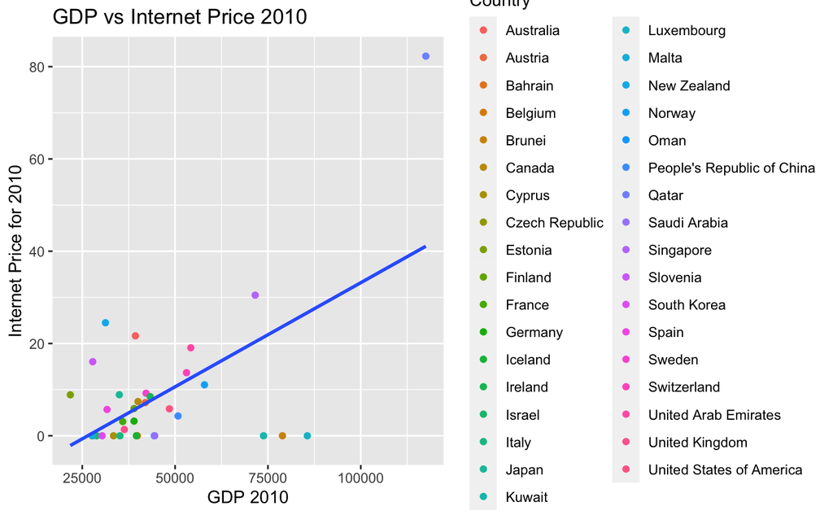

```r
# Visualization to show the relationship/correlation between GDP and Internet price
ggplot(data = random_countries, aes(g2010, i2010)) +
  geom_point(aes(color = Country), xmax = 1200) +
  ggtitle("GDP vs Internet Price 2010") +
  labs(y="Internet Price for 2010", x = "GDP 2010") +
  geom_smooth(method=lm, se=FALSE)
```

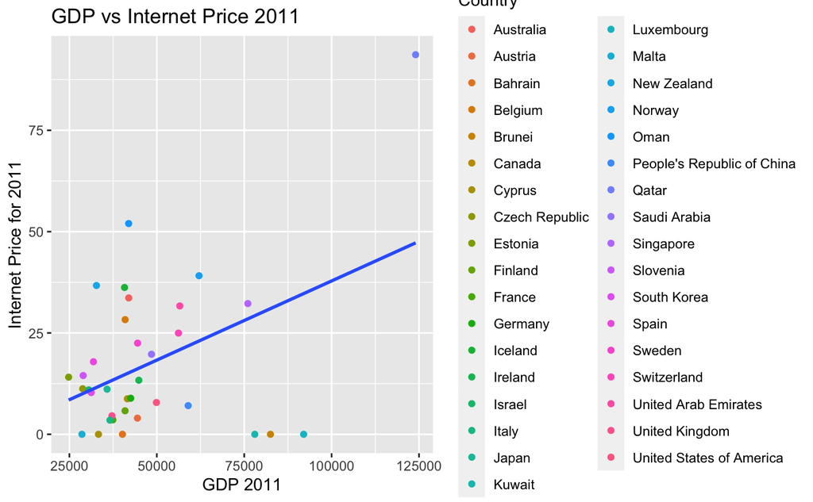

```r
ggplot(data = random_countries, aes(g2011, i2011)) +
  geom_point(aes(color = Country), xmax = 1200) +
  ggtitle("GDP vs Internet Price 2011") +
  labs(y="Internet Price for 2011", x = "GDP 2011") +
  geom_smooth(method=lm, se=FALSE)
```

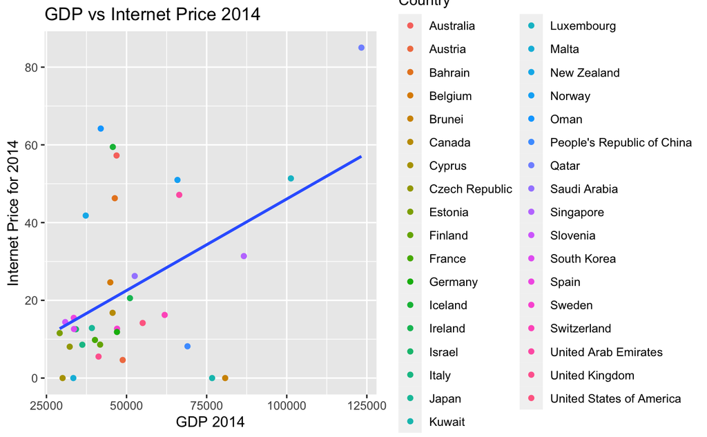

```r
ggplot(data = random_countries, aes(g2014, i2014)) +
  geom_point(aes(color = Country), xmax = 1200) +
  ggtitle("GDP vs Internet Price 2014") +
  labs(y="Internet Price for 2014", x = "GDP 2014") +
  geom_smooth(method=lm, se=FALSE)
```

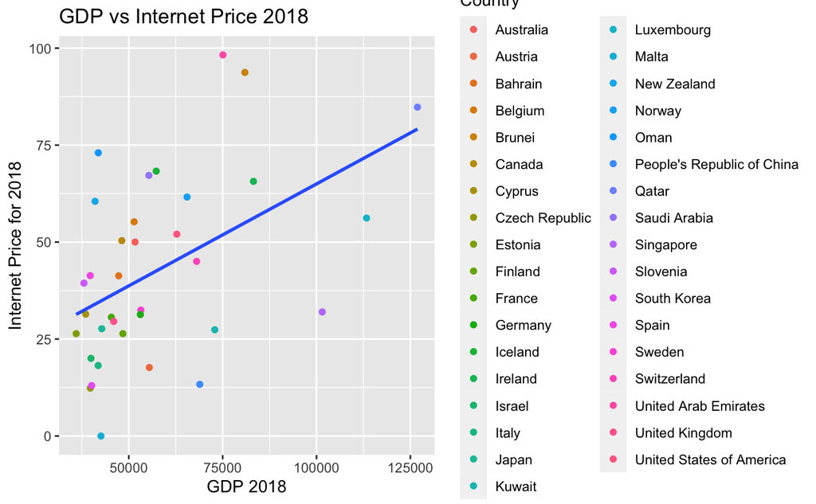

```r
ggplot(data = random_countries, aes(g2018, i2018)) +
  geom_point(aes(color = Country), xmax = 1200) +
  ggtitle("GDP vs Internet Price 2018") +
  labs(y="Internet Price for 2018", x = "GDP 2018") +
  geom_smooth(method=lm, se=FALSE)
```

## Technical challenge

Before reaching our visual portion of the project, one of our biggest challenges was our difficulty joining the GDP and Internet prices table. Many of the country names didn’t precisely match to join, causing some challenges in understanding and manipulating our data. Within our EDA, we had to manually rename all countries that had different spelling physically, were abbreviated, or were conflicting territories not recognized in a table. One specific country we came across a technical problem with was China. As there are a lot of conflicting regions and since only one internet price was labeled for the country, our only solution was to combine ‘Hong Kong SAR, China and ’Macao SAR, China.’ We manually fixed this case as there was no alternative option. So we combined the GDP of all three territories and evaluated it as one case, “The People’s Republic of China.” In the end, although we didn’t encounter any difficult technical situations, this was an obstacle that we had to work around as independent data collectors may have different views on territorial concerns.